# Project_701

n9617761

21 August2017

# BRIEF INTRODUCTION

This rmarkdown is based on data analysis on lowerback pain symptoms dataset.Primarily, it will summarize all insights gained by performing data analysis steps on lowerback pain dataset.This rmarkdown is divided the concrete modules of data analysis into three steps: 1) Data Cleaning and exploration 2) Data Visualization 3) Prediction model(Decision Tree,Naive Bayes,SVM,Random forest)

Firstly, to implement all the steps mentioned above importing the dataset is required.

*Data Source* the dataset has been downloded from Kaggle official website ( https://www.kaggle.com/sammy123/lower-back-pain-symptoms-dataset).

```r
#importing dataset
Spine_Data<-read.csv("~/Dataset_spine.csv", sep=",", header = TRUE)
```

# 1.DATA CLEANING AND EXPLORATION

Intially, it is important to check the number of rows and columns present in the entire dataset. dim() provides the information that there are 310 observation in dataset and 14 columns. The dataset comprises of 12 different features and 13th column classifies the data into two classes *Abnormal, Normal*.Also, all the features consist numeric data. While, inspecting the data set i realized that the 14th column holds unnecessary information. So, I removed that column from the dataset.

```r
# display number of rows and cols
dim(Spine_Data)
```

```
## [1] 310  14
```

```r
#display the structure
str(Spine_Data)
```

```
## 'data.frame':    310 obs. of  14 variables:
##  $ Col1     : num  63 39.1 68.8 69.3 49.7 ...
##  $ Col2     : num  22.55 10.06 22.22 24.65 9.65 ...
##  $ Col3     : num  39.6 25 50.1 44.3 28.3 ...
##  $ Col4     : num  40.5 29 46.6 44.6 40.1 ...
##  $ Col5     : num  98.7 114.4 106 101.9 108.2 ...
##  $ Col6     : num  -0.254 4.564 -3.53 11.212 7.919 ...
##  $ Col7     : num  0.745 0.415 0.475 0.369 0.543 ...
##  $ Col8     : num  12.6 12.9 26.8 23.6 35.5 ...
##  $ Col9     : num  14.5 17.5 17.5 12.7 16 ...
##  $ Col10    : num  15.3 16.78 16.66 11.42 8.87 ...
##  $ Col11    : num  -28.7 -25.5 -29 -30.5 -16.4 ...
##  $ Col12    : num  43.5 16.1 19.2 18.8 24.9 ...
##  $ Class_att: Factor w/ 2 levels "Abnormal","Normal": 1 1 1 1 1 1 1 1 1 1 ...
##  $ X        : Factor w/ 15 levels ""," Attribute10= cervical_tilt(numeric)",..: 1 1 15 1 1 9 10 11 12 13 ...
```

```r
#inspecting the data structure
summary(Spine_Data)
```

```
##       Col1             Col2             Col3             Col4
##  Min.   : 26.15   Min.   :-6.555   Min.   : 14.00   Min.   : 13.37
##  1st Qu.: 46.43   1st Qu.:10.667   1st Qu.: 37.00   1st Qu.: 33.35
##  Median : 58.69   Median :16.358   Median : 49.56   Median : 42.40
##  Mean   : 60.50   Mean   :17.543   Mean   : 51.93   Mean   : 42.95
##  3rd Qu.: 72.88   3rd Qu.:22.120   3rd Qu.: 63.00   3rd Qu.: 52.70
##  Max.   :129.83   Max.   :49.432   Max.   :125.74   Max.   :121.43
##
##       Col5             Col6              Col7              Col8
##  Min.   : 70.08   Min.   :-11.058   Min.   :0.00322   Min.   : 7.027
##  1st Qu.:110.71   1st Qu.:  1.604   1st Qu.:0.22437   1st Qu.:13.054
##  Median :118.27   Median : 11.768   Median :0.47599   Median :21.907
##  Mean   :117.92   Mean   : 26.297   Mean   :0.47298   Mean   :21.322
##  3rd Qu.:125.47   3rd Qu.: 41.287   3rd Qu.:0.70485   3rd Qu.:28.954
##  Max.   :163.07   Max.   :418.543   Max.   :0.99883   Max.   :36.744
##
##       Col9            Col10            Col11             Col12
##  Min.   : 7.038   Min.   : 7.031   Min.   :-35.287   Min.   : 7.008
##  1st Qu.:10.418   1st Qu.: 9.541   1st Qu.:-24.290   1st Qu.:17.189
##  Median :12.938   Median :11.954   Median :-14.623   Median :24.932
##  Mean   :13.065   Mean   :11.933   Mean   :-14.053   Mean   :25.646
##  3rd Qu.:15.890   3rd Qu.:14.372   3rd Qu.: -3.497   3rd Qu.:33.980
##  Max.   :19.324   Max.   :16.821   Max.   :  6.972   Max.   :44.341
##
##     Class_att                                        X
##  Abnormal:210                                         :296
##  Normal  :100    Attribute10= cervical_tilt(numeric)  :  1
##                  Attribute11=sacrum_angle(numeric)    :  1
##                  Attribute12= scoliosis_slope(numeric):  1
##                  Attribute7= pelvic_slope(numeric)    :  1
##                  Attribute8= Direct_tilt(numeric)     :  1
##                 (Other)                               :  9
```

```r
#check null values in dataset
any(is.na(Spine_Data))
```

```
## [1] FALSE
```

```r
# removing unnecessary column in the dataset
Spine_Data<- Spine_Data[,-14]
```

Next, i observed that columns does not have the header.The information about column attributes is describe in the [,14] column, which i already deleted.Therefore, I defined the column names.

```r
#define column data
names(Spine_Data)<-c ("Pelvic_incidence","Pelvic_tilt","Lumbar_lordosis_angle","Sacral_slope","Pelvic_radius","Degree_spondylolisthesis","Pelvic_slope","Direct_tilt","Thoracic_slope","Cervical_tilt","Sacrum_angle","Scoliosis_slope","Class_Att")
```

# 2. DATA VISUALIZATION

## 2.1 number of people with Abnormal/Normal Spine

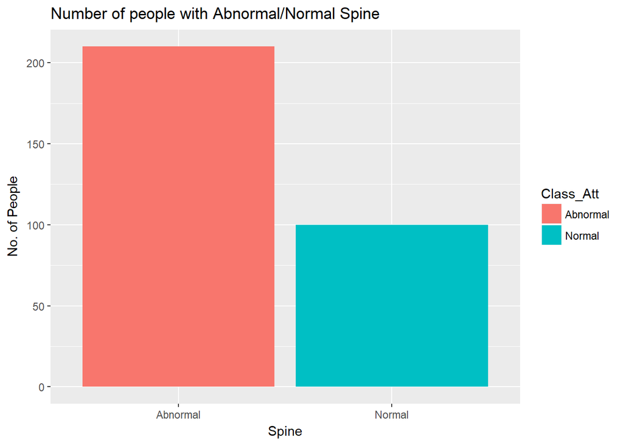

```r
# plot the number of people with Abnormal/Normal Spine
ggplot(Spine_Data, aes(x = Class_Att,fill= Class_Att)) + geom_bar()+ xlab("Spine")+ ylab("No. of People")+ggtitle("Number of people with Abnormal/Normal Spine")
```

The above barchart depicts that the people with abnormal spine are significantly more than the people with normal Spine.

## 2.2

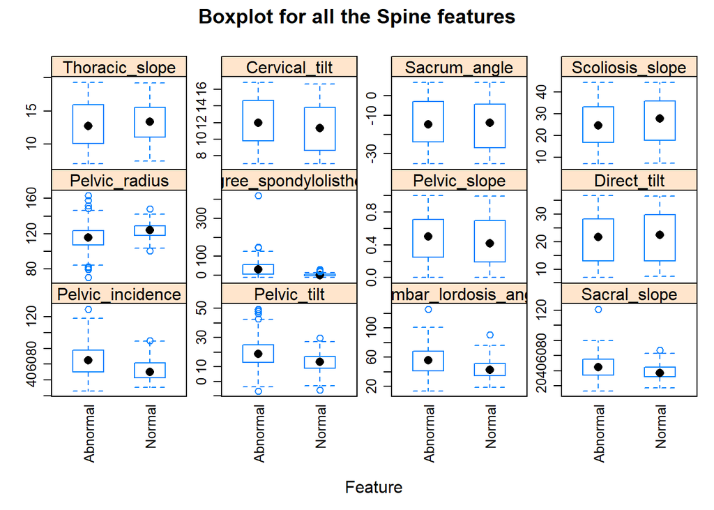

```r
# bloxplot to detect outliers
x <- Spine_Data[,1:12]
y <- Spine_Data[,13]
featurePlot(x = x,
           y = y,
           plot = "box",
           scales = list(y = list(relation="free"),
                         x = list(rot = 90)),
           auto.key = list(columns = 2),main="Boxplot for all the Spine features")
```

### Density by class

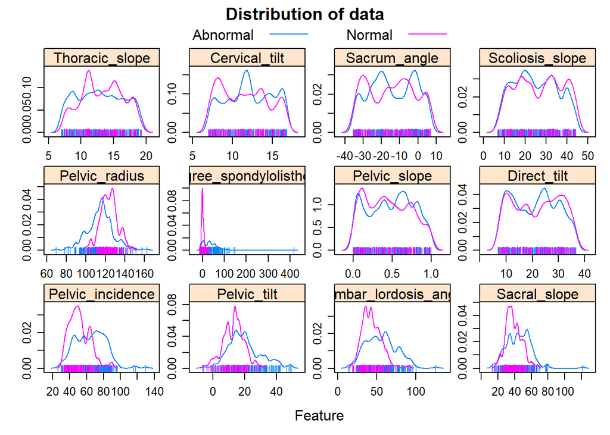

```r
# distribution of data
x1 <- Spine_Data[,1:12]
y1 <- Spine_Data[,13]
featurePlot(x = x1,
           y = y1,
           plot = "density",
           scales = list(x = list(relation="free"),
                          y = list(relation="free")),
           adjust = 0.5, cex.lab=0.5,
            pch="|",
           auto.key = list(columns = 2),main="Distribution of data")
```

### Correlation Plot by class

In the dot representation, blue indicates the positive correlation and the red shows the negative correlation. The bigger the dot the larger the relation.Here,The diagonal are perfectly positively correlated because it shows the correlation of each attribute with itself.

## Correlation Plot for Abnormal_Spine

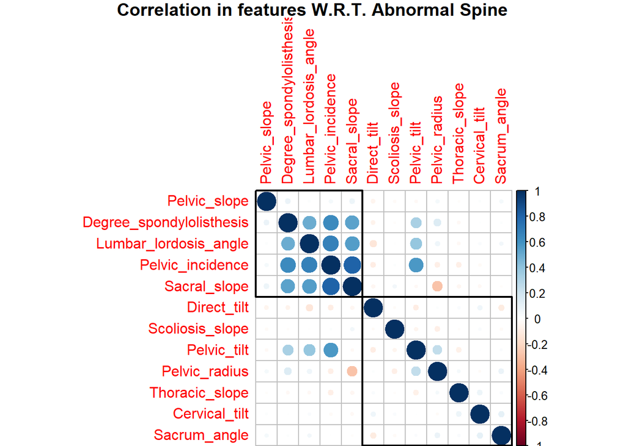

```r
# finding correlation using ggcorr
subset1<-subset(Spine_Data, Spine_Data$Class_Att=="Abnormal")
p1 <-cor(subset1[,1:12])
title <- "Correlation in features W.R.T. Abnormal Spine"
corrplot(p1, method = "circle", order="hclust", addrect=2, title = title,mar=c(0,0,1,0) )
```

This plot indicates the strong postive correlation between Degree_spondylolisthesis, lumbar_lordosis_angle,Pelvic_incidence, sarcal_slope.It derives that these correalated are responsible for Abnormal Spine.

## Correlation Plot for Normal_Spine

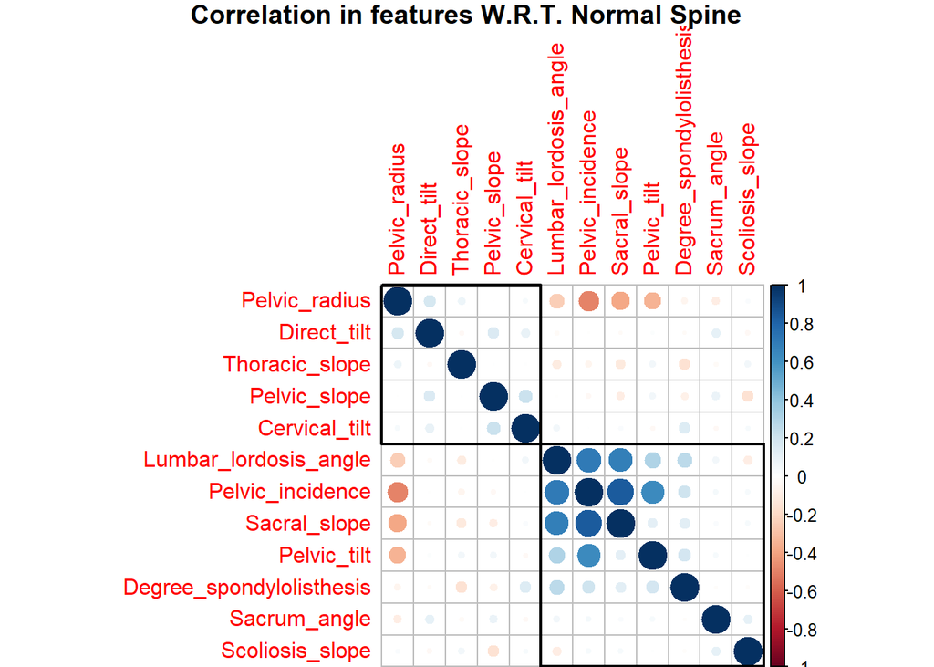

```r
subset2<-subset(Spine_Data, Spine_Data$Class_Att=="Normal")
p2 <-cor(subset2[,1:12])
corrplot(p2, method = "circle", order="hclust", addrect=2 ,title = "Correlation in features W.R.T. Normal Spine" ,mar=c(0,0,1,0)  )
```

From the above plot, it can be clearly seen that lumbar_lordosis_angle and Pelvic_incidence has positive corelation with Pelvic_incedence, Pelvic_tilt,and sarcal_slope.On the flipside, Pelvic_radius has negative correlation with lumbar_lordosis_angle, Pelvic_incidence,sarcal_slope and Pelvic_tilt.It implies that these correlated features are liable for normal Spine.

# PREDICTION MODELS

**Decision Tree Model**

First of all, here the data is divided the data into two groups - the *training* set, and the *test* set. The training data is used to build the tree, and the test data is used to examine how well it performed.

```r
# "seed" a random number generator
set.seed(1234)

# Split the data into 70% training, 30% test
ind <- sample(2, nrow(Spine_Data), replace=TRUE, prob=c(0.7, 0.3))
train_data <- Spine_Data[ind==1,]
test_data <- Spine_Data[ind==2,]
```

The `formula` dataframe below defines that *Class_Att* is the *target variable*, and all the other variables are *independent variables*.

```r
#classify Spine data
formula <- Class_Att ~ Degree_spondylolisthesis + Pelvic_incidence + Pelvic_tilt + Lumbar_lordosis_angle + Pelvic_radius + Sacral_slope + Cervical_tilt + Pelvic_slope + Direct_tilt + Thoracic_slope + Sacrum_angle + Scoliosis_slope

Spine_Data_ctree <- ctree(formula, data = train_data)
```

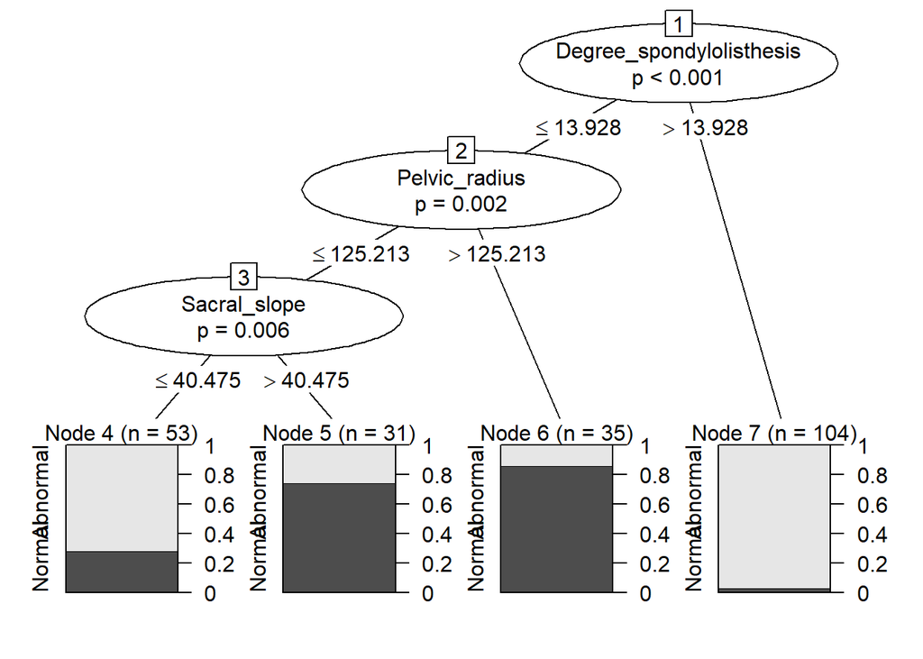

```r
plot(Spine_Data_ctree)
```

```r
table(predict(Spine_Data_ctree, newdata = test_data), test_data$Class_Att)
```

```
##
##            Abnormal Normal
##   Abnormal       57     10
##   Normal          1     19
```

The prediction model made 10 errors by classifying speciments of normal as abnormal.Also, it made 1 error for Abnormal class by classifying as normal.The main diagonal values shows the correct number of classification for each class.

```r
confusionMatrix(predict(Spine_Data_ctree, newdata = test_data), test_data$Class_Att)
```

```
## Confusion Matrix and Statistics
##
##           Reference
## Prediction Abnormal Normal
##   Abnormal       57     10
##   Normal          1     19
##
##                Accuracy : 0.8736
##                  95% CI : (0.785, 0.9352)
##     No Information Rate : 0.6667
##     P-Value [Acc > NIR] : 9.031e-06
##
##                   Kappa : 0.6916
##  Mcnemar's Test P-Value : 0.01586
##
##             Sensitivity : 0.9828
##             Specificity : 0.6552
##          Pos Pred Value : 0.8507
##          Neg Pred Value : 0.9500
##              Prevalence : 0.6667
##          Detection Rate : 0.6552
##    Detection Prevalence : 0.7701
##       Balanced Accuracy : 0.8190
##
##        'Positive' Class : Abnormal
##
```

```r
# Precision,Recall,F_measure
metric1<-confusionMatrix(predict(Spine_Data_ctree, newdata = test_data), test_data$Class_Att)
metric1$byClass[5:7]
```

```
## Precision    Recall        F1
## 0.8507463 0.9827586 0.9120000
```

The accuracy of Decision tree model is 87.36% which is quite high. **Naive Bayes Model**

```r
# load the libraries
library(caret)
library(klaR)

# define an 70/30 train/test split of the dataset
split=0.70
trainIndex <- createDataPartition(Spine_Data$Class_Att, list=FALSE)
data_train <- Spine_Data[ trainIndex,]
data_test <- Spine_Data[-trainIndex,]
# train a naive bayes model
model <- NaiveBayes(Class_Att~., data=data_train, kernel="linear" , scale=FALSE)

# make predictions
x_test <- data_test[,1:12]

y_test <- data_test[,13]

predictions <- predict(model, x_test)

# summarize results
confusionMatrix(predictions$class, y_test)
```

```
## Confusion Matrix and Statistics
##
##           Reference
## Prediction Abnormal Normal
##   Abnormal       74      9
##   Normal         31     41
##
##                Accuracy : 0.7419
##                  95% CI : (0.6656, 0.8088)
##     No Information Rate : 0.6774
##     P-Value [Acc > NIR] : 0.0492772
##
##                   Kappa : 0.4705
##  Mcnemar's Test P-Value : 0.0008989
##
##             Sensitivity : 0.7048
##             Specificity : 0.8200
##          Pos Pred Value : 0.8916
##          Neg Pred Value : 0.5694
##              Prevalence : 0.6774
##          Detection Rate : 0.4774
##    Detection Prevalence : 0.5355
##       Balanced Accuracy : 0.7624
##
##        'Positive' Class : Abnormal
##
```

The naive bayes model accuracy rate comes up with 74.19%.

```r
# Precision,Recall,F_measure
metric2<-confusionMatrix(predictions$class, y_test)
metric2$byClass[5:7]
```

```
## Precision    Recall        F1
## 0.8915663 0.7047619 0.7872340
```

**SVM(Support Vector Machine)**

```r
svm_model <- svm(Class_Att~., data = train_data, kernel="radial")
summary(svm_model)
```

```
##
## Call:
## svm(formula = Class_Att ~ ., data = train_data, kernel = "radial")
##
##
## Parameters:
##    SVM-Type:  C-classification
##  SVM-Kernel:  radial
##        cost:  1
##       gamma:  0.08333333
##
## Number of Support Vectors:  142
##
##  ( 77 65 )
##
##
## Number of Classes:  2
##
## Levels:
##  Abnormal Normal
```

```r
table(predict(svm_model, newdata = test_data), test_data$Class_Att)
```

```
##
##            Abnormal Normal
##   Abnormal       56      9
##   Normal          2     20
```

```r
confusionMatrix(predict(svm_model, newdata = test_data), test_data$Class_Att)
```

```
## Confusion Matrix and Statistics
##
##           Reference
## Prediction Abnormal Normal
##   Abnormal       56      9
##   Normal          2     20
##
##                Accuracy : 0.8736
##                  95% CI : (0.785, 0.9352)
##     No Information Rate : 0.6667
##     P-Value [Acc > NIR] : 9.031e-06
##
##                   Kappa : 0.6972
##  Mcnemar's Test P-Value : 0.07044
##
##             Sensitivity : 0.9655
##             Specificity : 0.6897
##          Pos Pred Value : 0.8615
##          Neg Pred Value : 0.9091
##              Prevalence : 0.6667
##          Detection Rate : 0.6437
##    Detection Prevalence : 0.7471
##       Balanced Accuracy : 0.8276
##
##        'Positive' Class : Abnormal
##
```

```r
F_metric<-confusionMatrix(predict(svm_model, newdata = test_data), test_data$Class_Att)
F_metric$byClass[5:7]
```

```
## Precision    Recall        F1
## 0.8615385 0.9655172 0.9105691
```

**Random Forest**

```r
#Random Forest Algorithm
# Split the data into 70% training, 30% test
set.seed(123)
ind <- sample(2, nrow(Spine_Data), replace=TRUE, prob=c(0.7, 0.3))
train_data <- Spine_Data[ind==1,]
test_data <- Spine_Data[ind==2,]
#random forest model for dataset
RF_model <- randomForest(Class_Att~., data = train_data , ntree= 100, proximity = T)
print(RF_model)
```

```
##
## Call:
##  randomForest(formula = Class_Att ~ ., data = train_data, ntree = 100,      proximity = T)
##                Type of random forest: classification
##                      Number of trees: 100
## No. of variables tried at each split: 3
##
##         OOB estimate of  error rate: 14.35%
## Confusion matrix:
##          Abnormal Normal class.error
## Abnormal      139     14  0.09150327
## Normal         18     52  0.25714286
```

```r
# importnce attribute of random forest model
RF_model$importance
```

```
##                          MeanDecreaseGini
## Pelvic_incidence                 6.778399
## Pelvic_tilt                      8.386787
## Lumbar_lordosis_angle            7.632247
## Sacral_slope                     8.185508
## Pelvic_radius                   11.067997
## Degree_spondylolisthesis        30.244988
## Pelvic_slope                     3.218006
## Direct_tilt                      2.938580
## Thoracic_slope                   3.985246
## Cervical_tilt                    5.335001
## Sacrum_angle                     3.777334
## Scoliosis_slope                  3.384973
```

```r
# view prediction
p1<-predict(RF_model,test_data)
```

```r
#confusion matrix
confusionMatrix(p1,test_data$Class_Att)
```

```
## Confusion Matrix and Statistics
##
##           Reference
## Prediction Abnormal Normal
##   Abnormal       47      8
##   Normal         10     22
##
##                Accuracy : 0.7931
##                  95% CI : (0.6929, 0.8725)
##     No Information Rate : 0.6552
##     P-Value [Acc > NIR] : 0.003624
##
##                   Kappa : 0.5492
##  Mcnemar's Test P-Value : 0.813664
##
##             Sensitivity : 0.8246
##             Specificity : 0.7333
##          Pos Pred Value : 0.8545
##          Neg Pred Value : 0.6875
##              Prevalence : 0.6552
##          Detection Rate : 0.5402
##    Detection Prevalence : 0.6322
##       Balanced Accuracy : 0.7789
##
##        'Positive' Class : Abnormal
##
```

```r
F_metric<-confusionMatrix(p1,test_data$Class_Att)
F_metric$byClass[5:7]
```

```
## Precision    Recall        F1
## 0.8545455 0.8245614 0.8392857
```

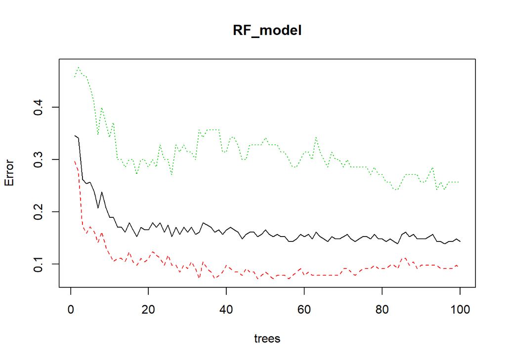

```r
# error rate in random forest model
plot(RF_model)
```

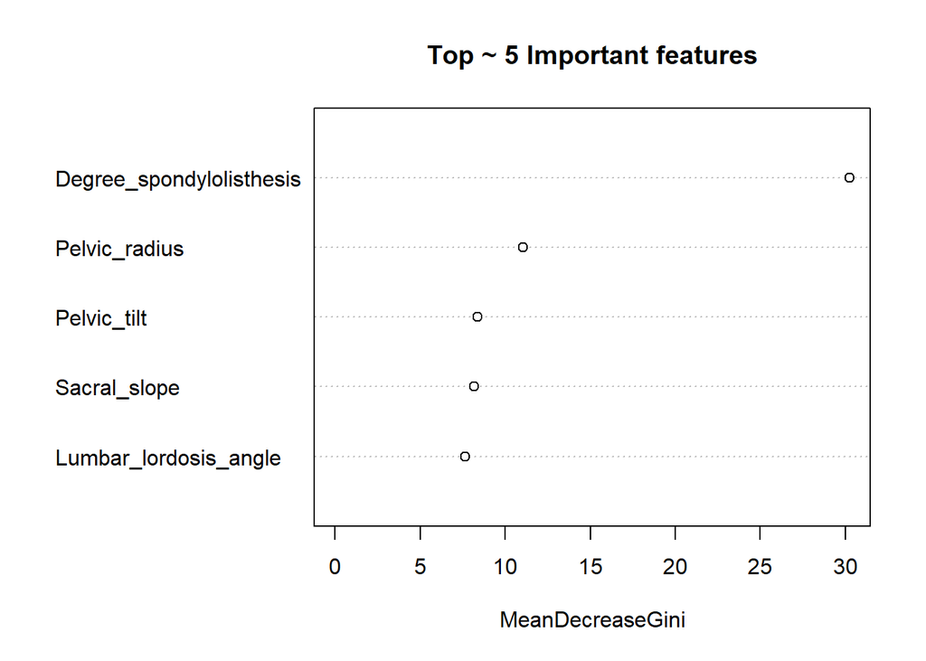

```r
# variable Importance
varImpPlot(RF_model,sort = T,n.var = 5, main = "Top ~ 5 Important features")
```

No doubt, Degree_Spondylolisthesis standouts among other features in the dataset.